# Michelle A Silveira

## Task 1

# Environment setup and data combination

```r
knitr::opts_chunk$set(echo = TRUE, message = FALSE, warning = FALSE)
library(tidyverse)
```

# Merge the 2 datasets

```r
# Using base read.table since your files are ';' separated
d1 <- read.table("student-mat.csv", sep = ";", header = TRUE)
d2 <- read.table("student-por.csv", sep = ";", header = TRUE)

# Using the original code / identity keys
j0 <- merge(
  d1, d2,
  by = c("school","sex","age","address","famsize","Pstatus",
         "Medu","Fedu","Mjob","Fjob","reason","nursery","internet")
)
print(nrow(j0))  # should be 382 students
```

```
[1] 382
```

```r
# USING INNER_JOIN

id_keys <- c(
  "school","sex","age","address","famsize","Pstatus",
  "Medu","Fedu","Mjob","Fjob","reason","nursery","internet"
)

j1 <- inner_join(
  d1, d2,
  by = id_keys,
  suffix = c(".math", ".por")
)

nrow(j1)   # should match j0 (382)
```

```
[1] 382
```

```r
head(names(j1), 20)  #  .math / .por suffixes
```

```
 [1] "school"          "sex"             "age"             "address"
 [5] "famsize"         "Pstatus"         "Medu"            "Fedu"
 [9] "Mjob"            "Fjob"            "reason"          "guardian.math"
[13] "traveltime.math" "studytime.math"  "failures.math"   "schoolsup.math"
[17] "famsup.math"     "paid.math"       "activities.math" "nursery"
```

# Inner-join on all shared columns except G1, G2, G3, paid, absences

```r
drop_cols <- c("G1","G2","G3","paid","absences")
by_excl5  <- setdiff(intersect(names(d1), names(d2)), drop_cols)

combined <- inner_join(d1, d2, by = by_excl5, suffix = c(".math", ".por"))

nrow(combined)
```

```
[1] 320
```

#Pick four categorical variables and convert them to factors in - the math table (d1), -the Portuguese table (d2), and -the combined table you just created

```r
cat_vars <- c("school","sex","address","famsize")

to_factor <- function(df) {
  df %>% mutate(across(all_of(cat_vars), ~ factor(.x)))
}

d1_fac       <- to_factor(d1)        # math
d2_fac       <- to_factor(d2)        # Portuguese
combined_fac <- to_factor(combined)  # joined table used in further tasks

# quick checks
sapply(d1_fac[cat_vars], is.factor)
```

```
 school     sex address famsize
   TRUE    TRUE    TRUE    TRUE
```

```r
sapply(d2_fac[cat_vars], is.factor)
```

```
 school     sex address famsize
   TRUE    TRUE    TRUE    TRUE
```

```r
sapply(combined_fac[cat_vars], is.factor)
```

```
 school     sex address famsize
   TRUE    TRUE    TRUE    TRUE
```

## Task 2

#Data Structure and missing

```r
# Structure
glimpse(combined_fac)
```

```
Rows: 320
Columns: 38
$ school        <fct> GP, GP, GP, GP, GP, GP, GP, GP, GP, GP, GP, GP, GP, GP, …
$ sex           <fct> F, F, F, F, M, M, F, M, M, F, F, M, M, M, F, F, F, M, M,…
$ age           <int> 18, 17, 15, 16, 16, 16, 17, 15, 15, 15, 15, 15, 15, 15, …
$ address       <fct> U, U, U, U, U, U, U, U, U, U, U, U, U, U, U, U, U, U, U,…
$ famsize       <fct> GT3, GT3, GT3, GT3, LE3, LE3, GT3, LE3, GT3, GT3, GT3, L…
$ Pstatus       <chr> "A", "T", "T", "T", "T", "T", "A", "A", "T", "T", "T", "…
$ Medu          <int> 4, 1, 4, 3, 4, 2, 4, 3, 3, 4, 2, 4, 4, 2, 4, 4, 3, 3, 4,…
$ Fedu          <int> 4, 1, 2, 3, 3, 2, 4, 2, 4, 4, 1, 4, 3, 2, 4, 4, 3, 2, 3,…
$ Mjob          <chr> "at_home", "at_home", "health", "other", "services", "ot…
$ Fjob          <chr> "teacher", "other", "services", "other", "other", "other…
$ reason        <chr> "course", "course", "home", "home", "reputation", "home"…
$ guardian      <chr> "mother", "father", "mother", "father", "mother", "mothe…
$ traveltime    <int> 2, 1, 1, 1, 1, 1, 2, 1, 1, 1, 3, 1, 2, 1, 1, 1, 3, 1, 1,…
```

[output cut: 25 more lines]

```r
summary(combined_fac)
```

```
 school   sex          age        address famsize     Pstatus
 GP:287   F:174   Min.   :15.00   R: 67   GT3:230   Length:320
 MS: 33   M:146   1st Qu.:16.00   U:253   LE3: 90   Class :character
                  Median :16.00                     Mode  :character
                  Mean   :16.52
                  3rd Qu.:17.00
                  Max.   :22.00
      Medu            Fedu           Mjob               Fjob
 Min.   :0.000   Min.   :0.000   Length:320         Length:320
 1st Qu.:2.000   1st Qu.:2.000   Class :character   Class :character
 Median :3.000   Median :3.000   Mode  :character   Mode  :character
 Mean   :2.872   Mean   :2.622
 3rd Qu.:4.000   3rd Qu.:4.000
 Max.   :4.000   Max.   :4.000
    reason            guardian           traveltime      studytime
 Length:320         Length:320         Min.   :1.000   Min.   :1.000
 Class :character   Class :character   1st Qu.:1.000   1st Qu.:1.000
 Mode  :character   Mode  :character   Median :1.000   Median :2.000
                                       Mean   :1.428   Mean   :2.084
                                       3rd Qu.:2.000   3rd Qu.:3.000
                                       Max.   :4.000   Max.   :4.000
    failures        schoolsup            famsup           paid.math
 Min.   :0.00000   Length:320         Length:320         Length:320
 1st Qu.:0.00000   Class :character   Class :character   Class :character
 Median :0.00000   Mode  :character   Mode  :character   Mode  :character
 Mean   :0.08125
 3rd Qu.:0.00000
 Max.   :3.00000
  activities          nursery             higher            internet
 Length:320         Length:320         Length:320         Length:320
 Class :character   Class :character   Class :character   Class :character
 Mode  :character   Mode  :character   Mode  :character   Mode  :character



   romantic             famrel         freetime         goout
 Length:320         Min.   :1.000   Min.   :1.000   Min.   :1.000
 Class :character   1st Qu.:4.000   1st Qu.:3.000   1st Qu.:2.000
 Mode  :character   Median :4.000   Median :3.000   Median :3.000
                    Mean   :3.987   Mean   :3.203   Mean   :3.069
```

[output cut: 8 more lines]

```
 Max.   :5.000   Max.   :5.000   Max.   :5.000   Max.   :75.000
    G1.math         G2.math         G3.math        paid.por
 Min.   : 5.00   Min.   : 0.00   Min.   : 0.00   Length:320
 1st Qu.: 9.00   1st Qu.: 9.00   1st Qu.: 9.00   Class :character
 Median :11.00   Median :11.00   Median :11.00   Mode  :character
 Mean   :11.29   Mean   :11.18   Mean   :11.04
 3rd Qu.:14.00   3rd Qu.:14.00   3rd Qu.:14.00
 Max.   :19.00   Max.   :19.00   Max.   :20.00
  absences.por        G1.por          G2.por          G3.por
 Min.   : 0.000   Min.   : 0.00   Min.   : 5.00   Min.   : 0.00
 1st Qu.: 0.000   1st Qu.:11.00   1st Qu.:11.00   1st Qu.:11.00
 Median : 2.000   Median :12.00   Median :12.00   Median :13.00
 Mean   : 3.247   Mean   :12.39   Mean   :12.57   Mean   :12.88
 3rd Qu.: 4.000   3rd Qu.:14.00   3rd Qu.:14.00   3rd Qu.:15.00
 Max.   :32.000   Max.   :19.00   Max.   :19.00   Max.   :19.00
```

```r
# Missingness (counts & percents)
miss_tbl <- combined_fac %>%
  summarize(across(everything(), ~ sum(is.na(.)), .names = "{.col}")) %>%
  pivot_longer(everything(), names_to = "var", values_to = "n_missing") %>%
  mutate(pct_missing = round(100 * n_missing / nrow(combined_fac), 1)) %>%
  arrange(desc(n_missing))
miss_tbl
```

```
# A tibble: 38 × 3
   var     n_missing pct_missing
   <chr>       <int>       <dbl>
 1 school          0           0
 2 sex             0           0
 3 age             0           0
 4 address         0           0
 5 famsize         0           0
 6 Pstatus         0           0
 7 Medu            0           0
 8 Fedu            0           0
 9 Mjob            0           0
10 Fjob            0           0
# ℹ 28 more rows
```

Categorical — One-/Two-/Three-Way Tables

```r
# Choose factor variables created earlier
tab1 <- table(combined_fac$school)                                      # one-way
tab2 <- table(combined_fac$school, combined_fac$sex)                    # two-way
tab3 <- table(combined_fac$school, combined_fac$sex, combined_fac$address)  # three-way

tab1; tab2; tab3
```

```
 GP  MS
287  33
```

```
       F   M
  GP 153 134
  MS  21  12
```

```
, ,  = R


       F   M
  GP  23  25
  MS  12   7

, ,  = U


       F   M
  GP 130 109
  MS   9   5
```

```r
# tab2["GP","F"] is the number of female students at school GP.
```

Categorical — Conditional Two-Way Table (two methods)

```r
# (a) Condition by filtering (address == "U"), then two-way table
tab2_cond_a <- combined_fac %>%
  filter(address == "U") %>%
  { table(.$school, .$sex) }

# (b) Build a 3-way table and subset the slice for address == "U"
tab3_all <- with(combined_fac, table(school, sex, address))
tab2_cond_b <- tab3_all[, , "U"]

tab2_cond_a; tab2_cond_b   # should match
```

```
       F   M
  GP 130 109
  MS   9   5
```

```
      sex
school   F   M
    GP 130 109
    MS   9   5
```

Categorical — dplyr group_by() + summarize() then pivot_wider()

```r
tab2_dplyr <- combined_fac %>%
  count(school, sex) %>%
  pivot_wider(names_from = sex, values_from = n, values_fill = 0)
tab2_dplyr
```

```
# A tibble: 2 × 3
  school     F     M
  <fct>  <int> <int>
1 GP       153   134
2 MS        21    12
```

Categorical — Stacked & Side-by-Side Bar Graphs

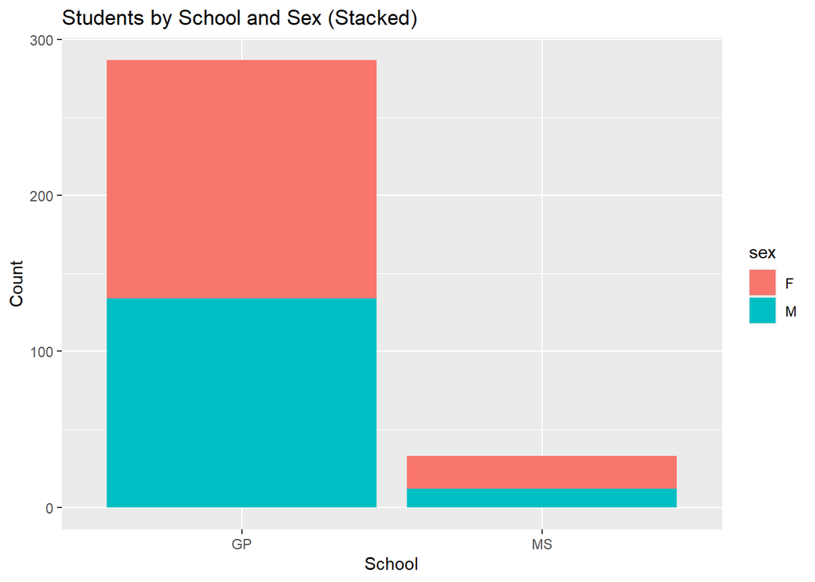

```r
# Stacked
ggplot(combined_fac, aes(x = school, fill = sex)) +
  geom_bar() +
  labs(x = "School", y = "Count", title = "Students by School and Sex (Stacked)")
```

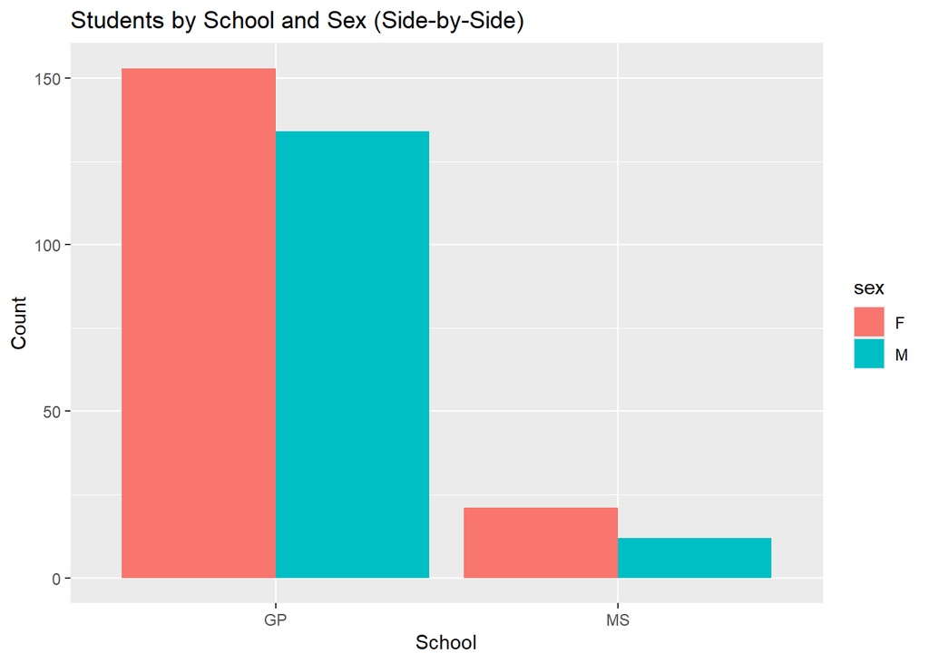

```r
# Side-by-side (dodged)
ggplot(combined_fac, aes(x = school, fill = sex)) +
  geom_bar(position = "dodge") +
  labs(x = "School", y = "Count", title = "Students by School and Sex (Side-by-Side)")
```

Numeric Variables — Choose three (include at least one G3)

```r
# Adjust names if yours differ
num_vars <- c("age", "absences.math", "G3.math")
```

Center & Spread (overall, then with a subset)

```r
# Overall
combined_fac %>%
  summarize(across(all_of(num_vars),
                   list(mean = ~mean(.x, na.rm=TRUE),
                        sd   = ~sd(.x,   na.rm=TRUE),
                        median = ~median(.x, na.rm=TRUE),
                        IQR    = ~IQR(.x,    na.rm=TRUE))))
```

```
  age_mean   age_sd age_median age_IQR absences.math_mean absences.math_sd
1   16.525 1.141687         16       1             5.4125         7.835205
  absences.math_median absences.math_IQR G3.math_mean G3.math_sd G3.math_median
1                    4              7.25     11.04063   4.302245             11
  G3.math_IQR
1           5
```